# STATS 769 Lab 01

The purpose of this lab is to get experience working within a Linux environment and to start learning to use some of the useful Linux tools.

**For this lab, you must work within Ubuntu 20.04 (via FlexIT) or on a cluster VM.**

In particular, you must process your R Markdown file within Ubuntu. On FlexIT that will require you to install the `rmarkdown` package.

To install `rmarkdown` on FlexIT, run following code in R and say “yes” to creating a personal R library.

```r
   Sys.setenv(MAKEFLAGS="-j6")
   install.packages("rmarkdown", Ncpus=6)
```

## The Data Set

We will continute to use the [Overseas merchandise trade dataset](https://www.stats.govt.nz/large-datasets/csv-files-for-download/overseas-merchandise-trade-datasets) which was introduced in Lab Zero.

For this lab we will have use a subset of the “Imports” dataset which has all imports of goods with the Harmonised Systems (HS) code starting with 8703 which denotes various types of vehicles. You can find the files on the VMs in the directory `/course/data/trade/vehicles`. Each file corresponds to one year (files are named `vehicles-YYYY.csv`) from 2000 to 2021.

For this lab, you will need to **download or copy the files to the same directory as your R Markdown file**. If you are on the FlexIT desktop, you can download and extract all files into the current directory using this command:

```bash
   curl https://www.stat.auckland.ac.nz/~su/769/vehicles.tar.gz | tar vxz
```

Every line represents the imports of a particular type of vehicle from a particular country in a particular month. It is just an extended set of the data used in Lab Zero - it includes more HS codes and all original fields as published by Stats NZ.

## Tasks

You should NOT use ‘tidyverse’ packages in your R code. Those packages are not (yet) installed on the virtual machines, so your code will not run on the virtual machines if you use the ‘tidyverse’ (and that will be bad when the marker runs your code on the virtual machines).

### Unix

In this section, you should not make use of R at all; instead you should write shell (`bash`) commands.

NOTE that you can include `bash` code chunks in your R Markdown file as well as `r` code chunks.

1. Show the Unix command that you would use to create a directory to hold the files for this lab (including your R Markdown file) and show the Unix command to navigate to that directory.

   **DO NOT** evaluate this code (i.e., use `eval=FALSE` in the chunk options).
2. Write a shell command that shows information about all the data files including the size in bytes for each of them.
3. Write a shell command that shows the number of lines in the `vehicles-2020.csv` file.
4. In Lab Zero we used all records with HS code (HSC) 8703231915. Write a shell command that extracts all records with HSC 8703231915 from all the files into a new file `car-imports.data`. Then write a shell command that counts the number of lines in the newy created file. Does it match the row count from Lab Zero?
5. Write a shell script which returns total counts (number of lines) for all HS codes (taking into account all files) in ascending count order and print the last five lines of the output. It should look something like this:

   ```
      1853 8703248005
      1868 8703248003
      1931 8703328003
      2985 8703238005
      3003 8703238003
   ```

6. We are only interested in new, gasoline-powered personal vehicles. Those have the following HS codes depending on the engine: 8703218006, 8703228003, 8703238003, 8703248003, 8703211915, 8703221915, 8703231915, 8703241915. Write one or more shell comands that that create a valid CSV file named `new-car-imports.csv` from all the vehicle data files containing only the HS codes listed above.

### Import

7. Read the `new-car-imports.csv` CSV file into R (if you did not finish the above, you can also find a copy in `/course/data/trade` on the VMs and on Canvas). Your code should generate a data frame `cars`.

### Clean

8. The original column names are unwieldly, write R code to replace them with shorter alternatives. Numeric variables seem to be encoded as strings and contain thousands separators. Write R code to turn them into proper numeric vectors. Similarly, create a new variable `Date` based on the `Month` variable which is contiguous and more suitable for modeling.

   The result should look something like this:

   ```r
      str(cars)
      'data.frame': 9451 obs. of  11 variables:
       $ Month        : int  200001 200001 200001 200001 200001 200001 200001 200001 200001 200001 ...
       $ HSC          : num  8.7e+09 8.7e+09 8.7e+09 8.7e+09 8.7e+09 ...
       $ HSDescription: chr  "Vehicles; spark-ignition internal combustion reciprocating piston engine, cylinder capacity not exceeding 1000c"| __truncated__ "Vehicles; spark-ignition internal combustion reciprocating piston engine, cylinder capacity exceeding 1000cc bu"| __truncated__ "Vehicles; spark-ignition internal combustion reciprocating piston engine, cylinder capacity exceeding 1000cc bu"| __truncated__ "Vehicles; spark-ignition internal combustion reciprocating piston engine, cylinder capacity exceeding 1000cc bu"| __truncated__ ...
       $ Unit         : chr  "NMB" "NMB" "NMB" "NMB" ...
       $ Country      : chr  "Japan" "Spain" "France" "United Kingdom" ...
       $ VFD          : num  410242 125408 662198 44266 68133 ...
       $ CIF          : num  432496 137791 730063 49558 72299 ...
       $ Quantity     : num  42 11 36 3 5 85 144 48 159 2 ...
       $ Status       : chr  "Final" "Final" "Final" "Final" ...
       $ Unknown      : logi  NA NA NA NA NA NA ...
       $ Date         : Date, format: "2000-01-01" "2000-01-01" ...
   ```

### Explore

9. Create a bar plot of total imported value (`VFD`) by country. What do we learn? Can you identify all countries in the plot? If not, propose a solution that allows us to focus on the top countries by volume - possibly also suggesting a transformation if appropriate.
10. We want to look at the evolution of the import value by HS code over time. Compute the aggregated monthly import value (`VFD`) of each HS code and draw a line plot of the result.

    Hint: `xtabs` and `matplot` are your friends here - look up the usage in R help if necessary.

    The result should look something like this:

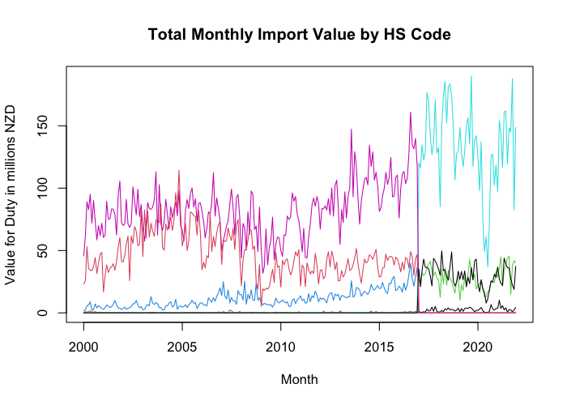

    What does the plot tell us? Support any hypotheses by R code. Propose a solution to make the dataset consistent for further analysis (no code needed, just describe your apporach).

### Model

11. Let us focus on the imports from Germany, i.e., the following should be performed on the subset of `cars` where the `Country` is Germany. We want to predict the total monthly new car `VFD` import value (aggregated over all HS codes) over time. In order to make interpretation easier, scale the `VFD` variable such that its unit are millions of NZD. We are going to limit ourselves to simple linear regression.

    Generate training and test sets, where the training set is 90% of the data and the test set is only 10% of the data. Choose the dataset partitions such that you are testing with future data (relative to training).

    Fit two models to the training data: a simple overall mean and a linear regression model with the `Date` as a predictor variable.

    Calculate RMSE for the predictions of the two models on the test set. Which model performs better?

    Your results should be similar to these:

    ```
       RMSE for mean:
       [1] 8.379609
       RMSE for linear model:
       [1] 11.52066
    ```

    Plot the model predictions, it shoud look something like this (dotted line denotes the split between the training and test data, you don’t need worry about creating the pink label):

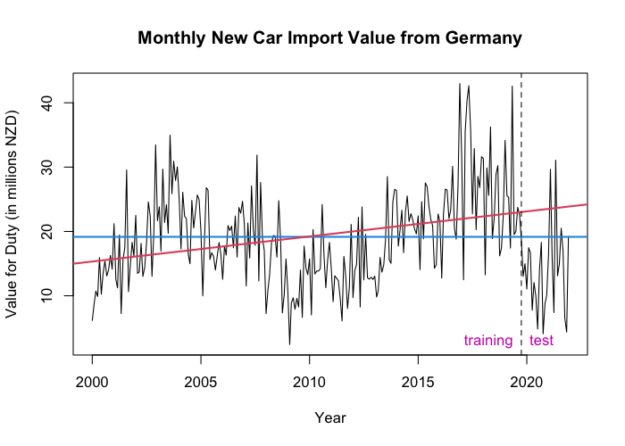

    Do you think the linear model is sensible? Can you explain the obtained results?

## Summary

12. Write a summary of your findings.

# The Report

Your submission should consist of an R Markdown document, submitted via Canvas. You should write your document so that it can be processed on a computer without any manual intervention. For example, do not include any calls to `setwd()` or `file.choose()`. You should write code that assumes that data files are in the current working directory or at a fixed location (`/course/data/...`) on the VMs. Also submit a processed version of your R Markdown document (an HTML document) in case we cannot process your document on the VM.

Your report should include:

- A brief description of the data.
- For each task, R code AND a brief text commentary.
- A summary of the entire report.

# Marking

Marks will be lost for:

- R Markdown file is missing.
- R Markdown file does not run.
- Processed file (HTML) is missing.
- Section of the report is missing.
- Unintelligible, or confusing, or irrelevant summary.
- Significantly poor R (or other) code.
- Overly verbose code, output, or commentary.